# Lab 8 - Introduction to linear regression - KEY

total - 90 points

**Load MLB11 dataset:**

```r
load(url("https://stat.duke.edu/~mc301/data/mlb11.RData"))
```

## Exercises:

#### Exercise 1:

```
6pts
- 3 for plot
- 3 for linear relation
```

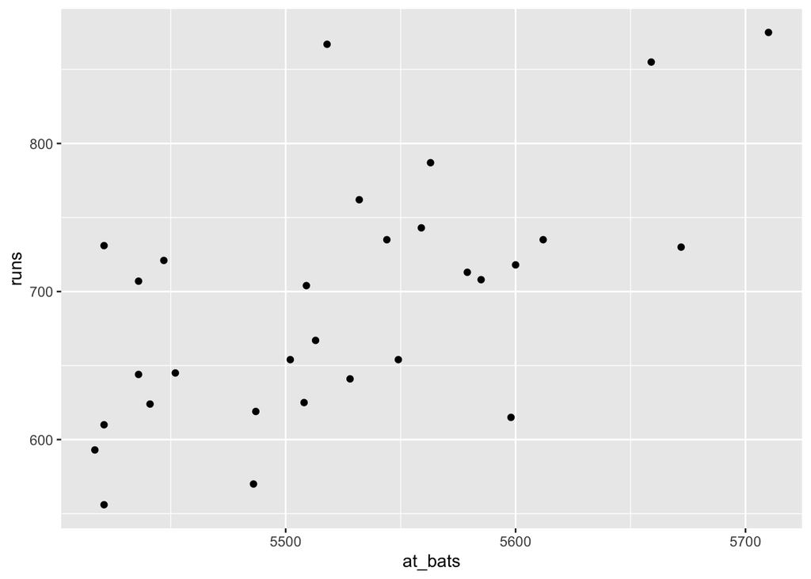

```r
qplot( x = at_bats, y = runs, data = mlb11)
```

Yes, there is a liner relationship between runs and at_bats since there is no apparent curvature. Given data of at_bats, we can predict number of runs with a linear model.

#### Exercise 2:

```
12pts
- 4 for relationship
- 4 for form/direction/strength
- 4 for outlier - name not required
```

There is a positive linear relationship between the two variables. Correlation coefficient is 0.610627 (indicating a relatively strong positive correlation). New York Yankees is an outlier: the distance from the actual number of runs to the fitted value given number at_bats are unusually large.

#### Exercise 3:

```
8pts total
- 4 for the plot made by plot_ss
- 4 for reporting a sum of squares
```

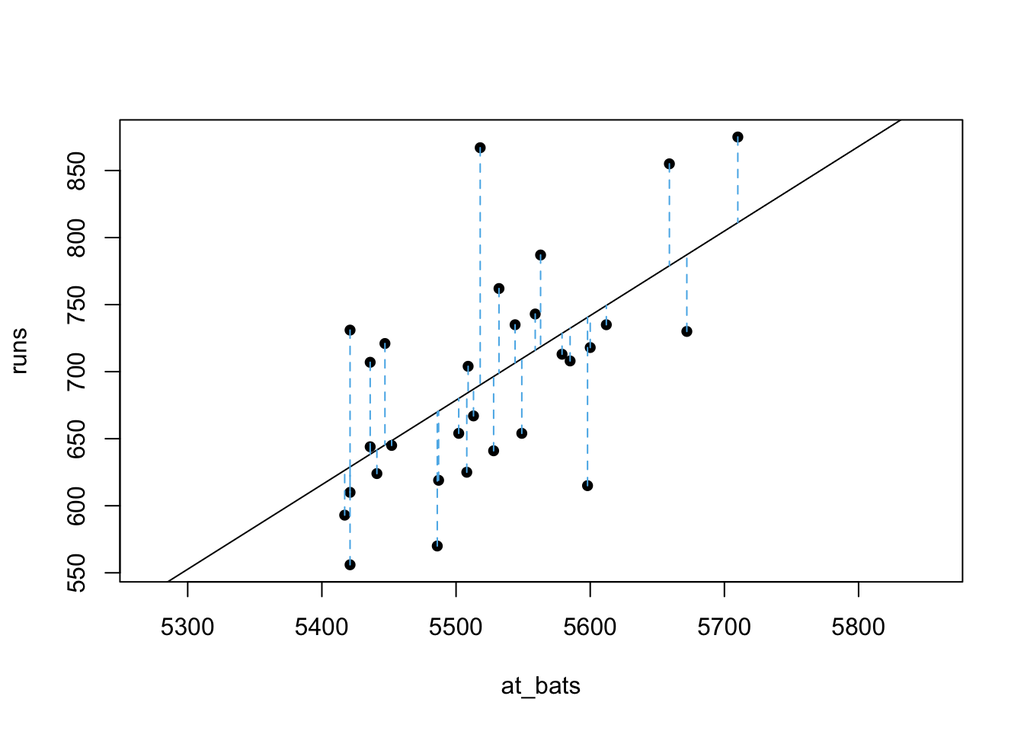

```
## Click two points to make a line.

## Call:
## lm(formula = y ~ x, data = pts)
##
## Coefficients:
## (Intercept)            x
##  -2789.2429       0.6305
##
## Sum of Squares:  123721.9
```

```r
plot_ss(x = at_bats, y = runs, data = mlb11)
```

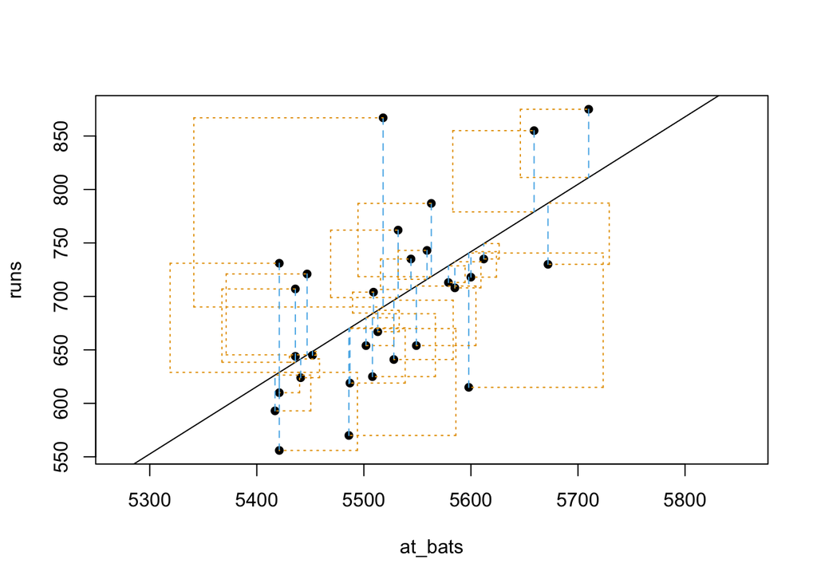

```
## Click two points to make a line.

## Call:
## lm(formula = y ~ x, data = pts)
##
## Coefficients:
## (Intercept)            x
##  -2789.2429       0.6305
##
## Sum of Squares:  123721.9
```

```r
plot_ss(x = at_bats, y = runs, data = mlb11, showSquares = TRUE)
```

Answers may vary. Some number > 123721.9.

#### Exercise 4:

```
8pts total
- 4 for regression equation
- 4 for explanation
```

```r
model=lm(runs~homeruns,data=mlb11)
summary(model)
```

```
##
## Call:
## lm(formula = runs ~ homeruns, data = mlb11)
##
## Residuals:
##     Min      1Q  Median      3Q     Max
## -91.615 -33.410   3.231  24.292 104.631
##
## Coefficients:
##             Estimate Std. Error t value Pr(>|t|)
## (Intercept) 415.2389    41.6779   9.963 1.04e-10 ***
## homeruns      1.8345     0.2677   6.854 1.90e-07 ***
## ---
## Signif. codes:  0 '***' 0.001 '**' 0.01 '*' 0.05 '.' 0.1 ' ' 1
##
## Residual standard error: 51.29 on 28 degrees of freedom
## Multiple R-squared:  0.6266, Adjusted R-squared:  0.6132
## F-statistic: 46.98 on 1 and 28 DF,  p-value: 1.9e-07
```

yhat=415.2389 + 1.8345 * homeruns

For each unit increase in homeruns, on average runs will increase 1.8345 units.

#### Exercise 5:

```
12pts total
- 5 for prediction
- 4 for comparing the prediction with the actual data and calculating the residual
- 3 for overestimation
```

```r
m1 = lm(runs ~ at_bats, data = mlb11)

predictionPoint = m1$coefficients[1]+m1$coefficients[2]*5578

AB_5579 = mlb11 %>%
  filter(at_bats == 5579) %>%
  select(runs)
AB_5579 - predictionPoint
```

```
##        runs
## 1 -14.96497
```

residual = actual data - prediction

The residual is -14.96 and thus our model overestimates the value here

#### Exercise 6:

```
5pts total
```

#### Exercise 7:

```
5pts total
```

#### Exercise 8:

```
5pts total
```

Yes, the variability of runs doesn’t change with different values of at_bats.

## More Practice

#### 9:

```
9pts total
- 2 for choosing a variable that is not "at_bats"
- 2 for making a scatterplot
- 2 for fitting a linear model
- 3 for the relationship
```

Answers may vary. I chose wins as a predictor.

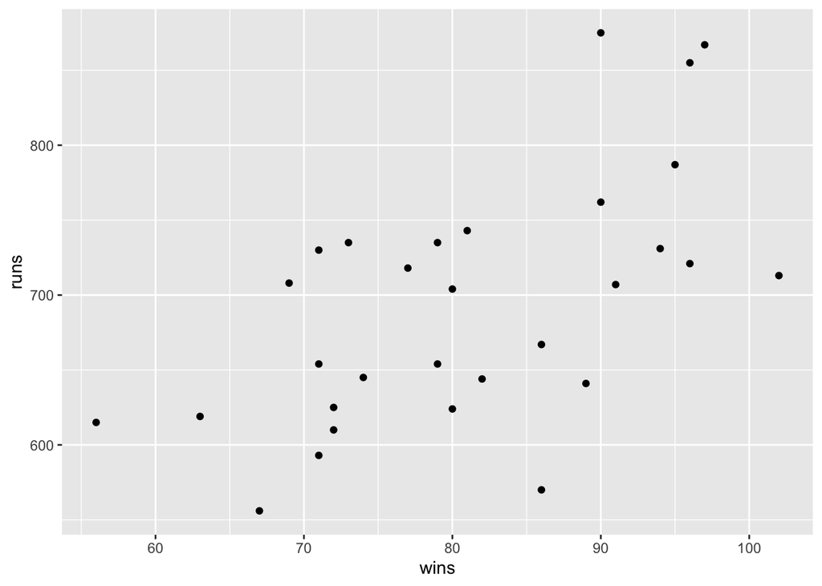

```r
qplot(x = wins, y = runs, data = mlb11)
```

```r
model2=lm(runs~wins,data=mlb11)
```

Since there is no apparent curvature, there is linear relationship between wins and runs.

#### 10:

```
7pts total
- 2 *each* for reporting $R^2$ of each of the two models,
- 3 for conclusion
```

```r
summary(m1)$r.squared
```

```
## [1] 0.3728654
```

```r
summary(model2)$r.squared
```

```
## [1] 0.3609712
```

$R^2$ of model2 = 0.361 is slightly lower than $R^2$ of m1 = 0.373. `At_bats` is a slightly better predictor of runs than wins.

#### 11:

```
13pts total
- 5 for residual plot
- 5 for histogram/ Q-Q plot
- 3 for stating whether or not the conditions are met
```

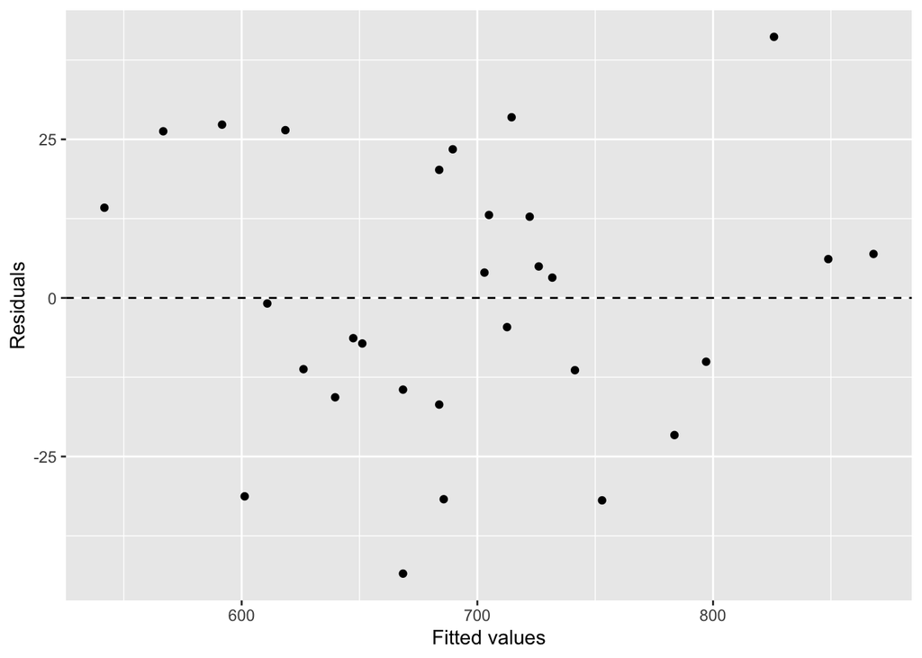

```r
modelnew=lm(runs~new_obs,data=mlb11)
qplot(x = .fitted, y = .resid, data = modelnew) +
  geom_hline(yintercept = 0, linetype = "dashed") +
  xlab("Fitted values") +
  ylab("Residuals")
```

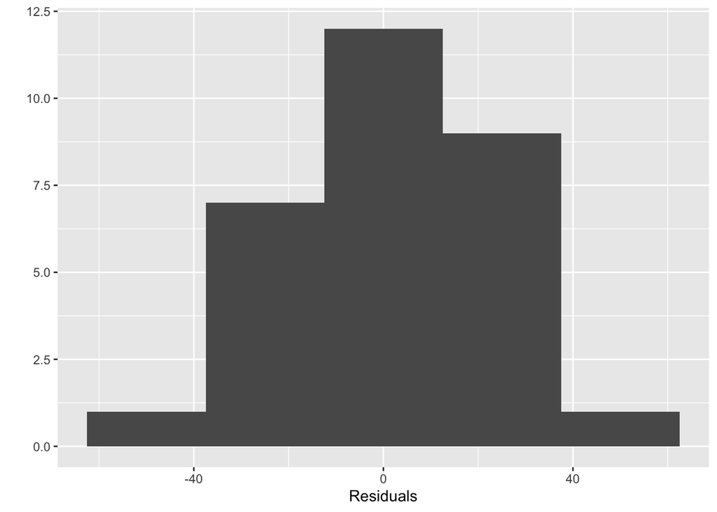

```r
qplot(x = .resid, data = modelnew, geom = "histogram", binwidth = 25) +
  xlab("Residuals")
```

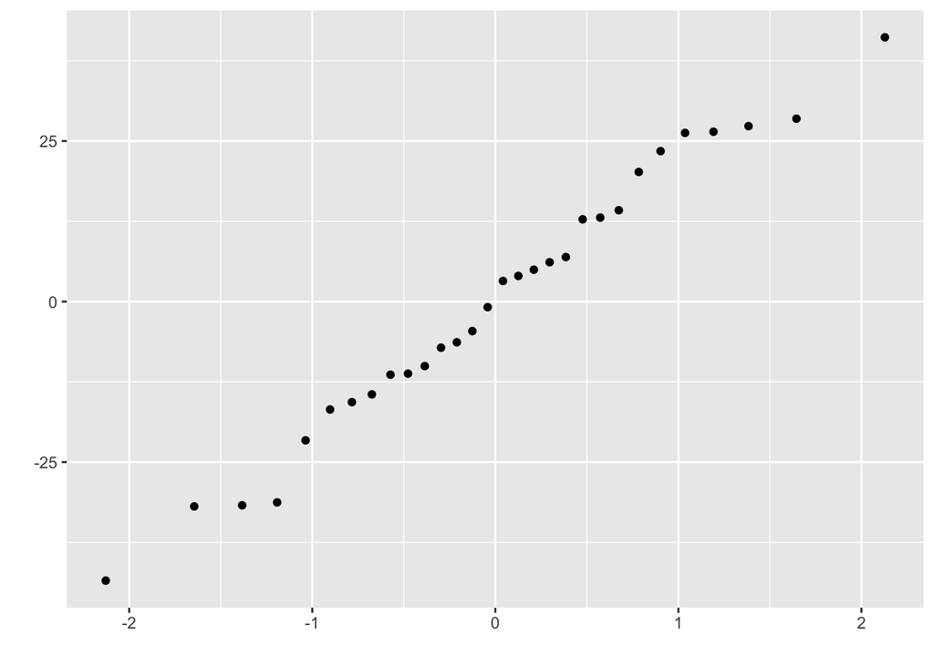

```r
qplot(sample = .resid, data = modelnew, stat = "qq")
```

The residuals are centered around 0, with no apparent change due to different values of predictor. From the histogram and Q-Q plot, they are normally distributed.